# **Addition Insights - Companies to Watch Newsletter**

May 9, 2022

## **Mondu**

**Company:** Mondu  
**Country (Operating):** Stresemannstraße 123, 10963 Berlin, Germany  
**Founded Date:** January 01, 2021  
**Homepage:** https://www.mondu.ai  
**Current Headcount:** 76  
**Lifetime Funding:** $43,600,000  
**Number of Funding Rounds:** 2  
**Investors:** Cherry Ventures, Valar Ventures LLC, FinTech Collective, Discovery Ventures  
**Most Recent Funding:** EARLY STAGE VC - April 25, 2022  
**Sectors:** Financial Technology, Financial / Insurance Services  
**Description:** Simplifying the financial lives of SMBs so that they can focus on business

### **Headcount**

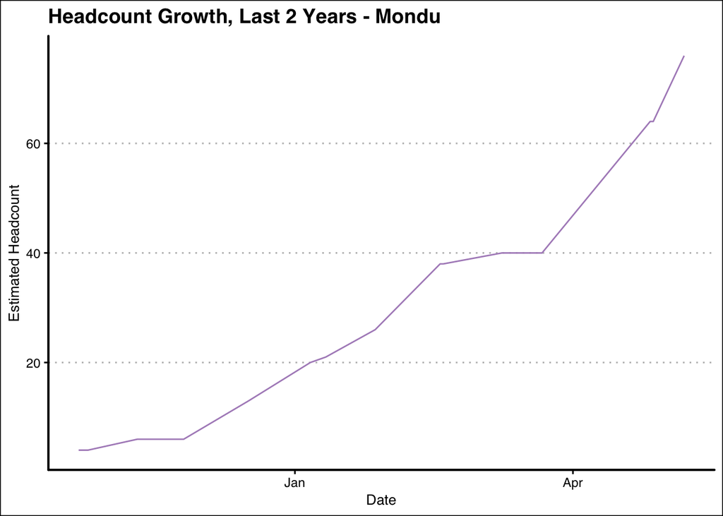

## **Z1**

**Company:** Z1  
**Country (Operating):** Rua Bandeira Paulista nº 300, Apartment 205, Itaim Bibi, Sao Paulo, 05604-010, Brazil  
**Founded Date:** January 01, 2019  
**Homepage:** https://z1.app  
**Current Headcount:** 154  
**Lifetime Funding:** $12,639,418  
**Number of Funding Rounds:** 4  
**Investors:** Goodwater Capital, Homebrew, Rebel Fund, KASZEK, Clocktower Technology Ventures, MANTIS Venture Capital, Soma Capital, MAYA CAPITAL, The Chainsmokers, Rebel, Y Combinator, Gaingels, Ariel Lambrecht  
**Most Recent Funding:** SERIES A - November 22, 2021  
**Sectors:** W21, Financial Technology, Financial / Insurance Services  
**Description:** Z1 is a digital banking app made for teenagers and young adults where teenagers can learn financial independence.

### **Headcount**

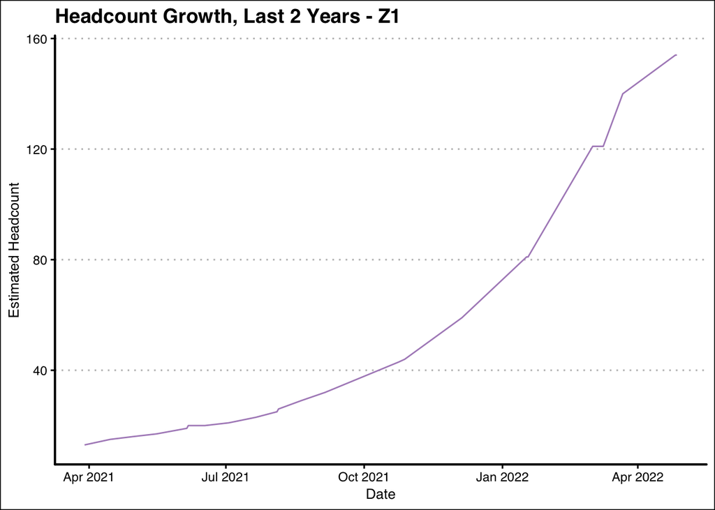

## **Clara**

**Company:** Clara  
**Country (Operating):** Amsterdam 121, Col. Hipódromo, Alcaldía Cuauhtémoc, Mexico City, 06100, Mexico  
**Founded Date:** January 01, 2020  
**Homepage:** https://www.clara.com/es-mx  
**Current Headcount:** 276  
**Lifetime Funding:** $158,500,000  
**Number of Funding Rounds:** 3  
**Investors:** SV Angel, Coatue Management, KASZEK, monashees, Liquid 2 Ventures, Alter Global, Canary, VentureSouq, Picus Capital, Soma Capital, BoxGroup, DST Global, Avid Ventures, Adapt, Canary Ventures, Exponent, ICONIQ Growth, JAM Fund, General Catalyst, A* Capital, Y Combinator, Global Founders Capital, Ariel Lambrecht, Daniel Vogel, Sergio Furio, Sebastian Mejia, Gaingels, Karim Atiyeh, Max Burger, Justin Mateen, Mike Levinthal, Manolo Atala, Nicky Goulimis, Ricardo Weder, Sebastián Castro Galnares, Travis Foxhall, Howard Han, Oliver Jung  
**Most Recent Funding:** SERIES B - December 06, 2021  
**Sectors:** Financial Technology, Financial / Insurance Services  
**Description:** Clara is End-to-end spend management for companies and helps businesses grow.

### **Headcount**

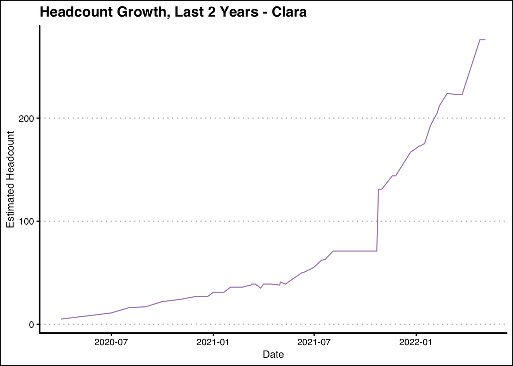

## **Cowrywise**

**Company:** Cowrywise  
**Country (Operating):** 5C Reverend Ogunbiyi Street, Ikeja, GRA, Lagos, 100001, Nigeria  
**Founded Date:** January 01, 2017  
**Homepage:** https://cowrywise.com  
**Current Headcount:** 595  
**Lifetime Funding:** $3,630,000  
**Number of Funding Rounds:** 5  
**Investors:** Kairos HQ, BFA Global, Quona Capital, VentureSouq, Microtraction, NULL, Tsadik Foundation, Sahil Lavingia, Y Combinator, Founder, Gumroad  
**Most Recent Funding:** SERIES A - February 11, 2021  
**Sectors:** Financial Technology, AI / ML, Financial / Insurance Services  
**Description:** Cowrywise is a FinTech company that democratizes access to premium financial services by making these services available to the mass market.

### **Headcount**

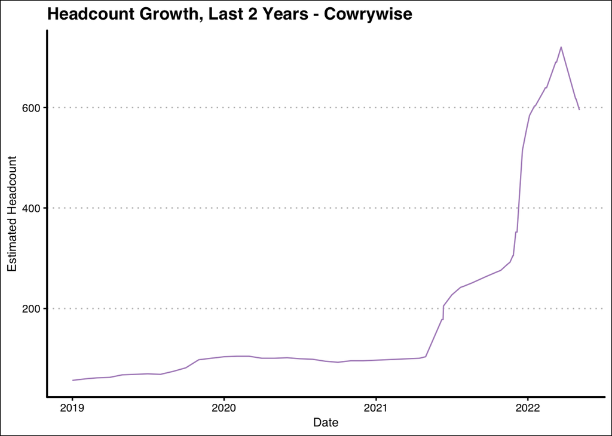

### **Traffic**

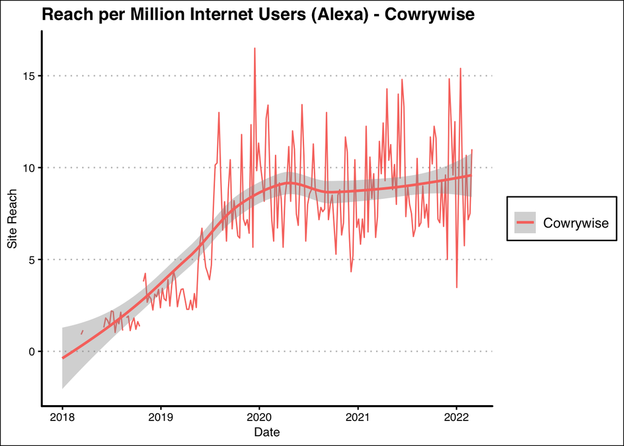

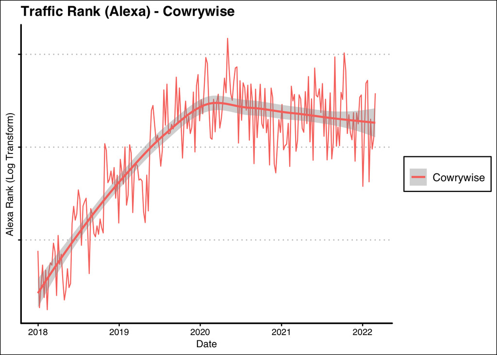

### **Google Trends**

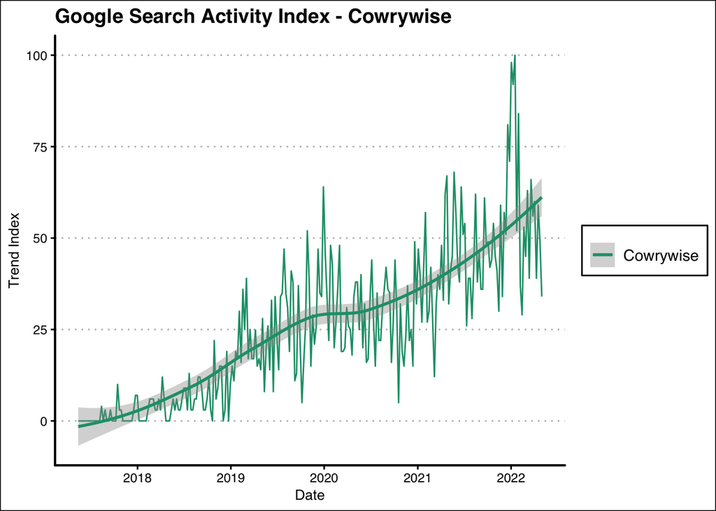

## **Treinta**

**Company:** Treinta  
**Country (Operating):** Bogotá, Distrito Especial, Colombia  
**Founded Date:** January 01, 2020  
**Homepage:** https://treinta.co  
**Current Headcount:** 260  
**Lifetime Funding:** $46,125,000  
**Number of Funding Rounds:** 3  
**Investors:** Goodwater Capital, LionTree LLC, Luxor Capital Group, Outbound Ventures, TwentyTwo VC, Commerce Ventures, Acacia Venture Partners, Houston Angel Network, FJ Labs, Soma Capital, First Check Ventures, TEN13, Rhombuz VC, LionTree Partners, Varsha Rao, Levels Up Ventures, Y Combinator, Prosus Group, Ethos VC, Erik Peterson – Political Science, Raffael Johnen, Aaron Gathmann, Carlos Kronen, Kube VC, PayU, Eric K., Nitesh Banta, Sherwin Gandhi  
**Most Recent Funding:** SERIES A - April 05, 2022  
**Sectors:** W21, Financial Technology, Financial / Insurance Services, SaaS  
**Description:** Digital ledger app for Latin American microbusinesses.

### **Headcount**

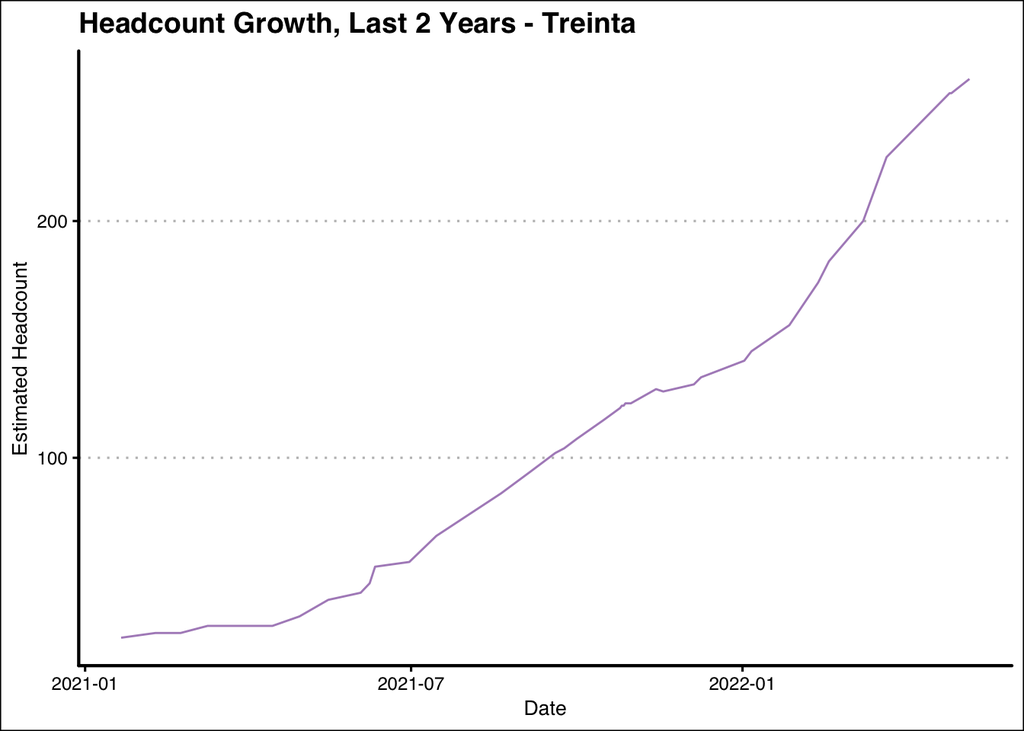

### **Google Trends**

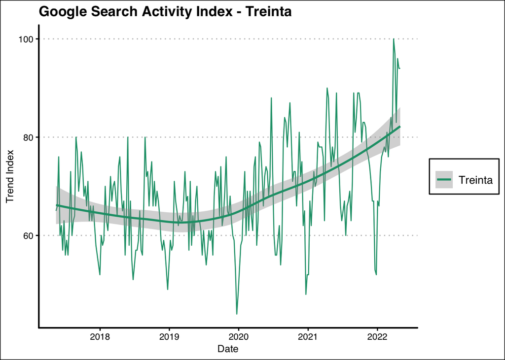

## **Juni**

**Company:** Juni  
**Country (Operating):** Kungsportsavenyn 21, 411 36 Gothenburg, Sweden  
**Founded Date:** January 01, 2020  
**Homepage:** https://juni.co  
**Current Headcount:** 144  
**Lifetime Funding:** $75,874,308  
**Number of Funding Rounds:** 2  
**Investors:** Cherry Ventures, EQT Ventures, FJ Labs, Felix Capital, DST Global, Jarno Vanhatapio, Johan Bendz, NULL  
**Most Recent Funding:** SERIES A - October 14, 2021  
**Sectors:** Financial Technology, Sales / Ads / Marketing / BD, Financial / Insurance Services, SaaS, E-Commerce  
**Description:** Juni is a fintech company that develops a banking app and platform for e-commerce and online marketing entrepreneurs.

### **Headcount**

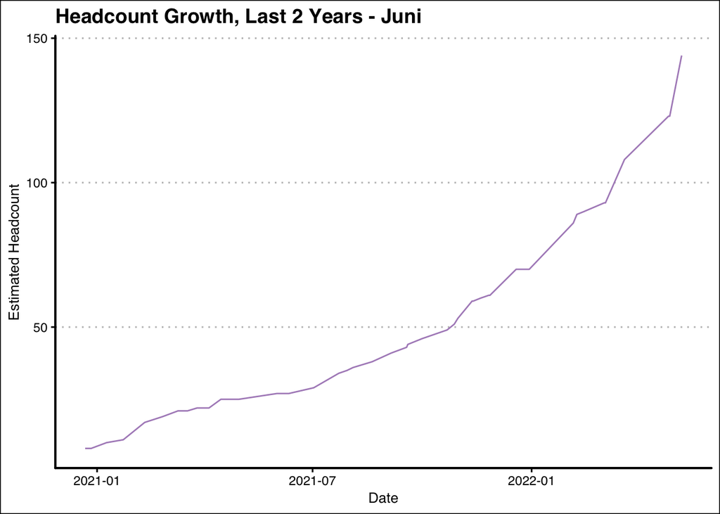

## **Moss | All-in-one spend management**

**Company:** Moss | All-in-one spend management  
**Country (Operating):** Ziegelstraße 16, 10117 Berlin, Germany  
**Founded Date:** January 01, 2019  
**Homepage:** https://getmoss.com  
**Current Headcount:** 401  
**Lifetime Funding:** $104,900,000  
**Number of Funding Rounds:** 4  
**Investors:** Cherry Ventures, Rocket Internet SE, Valar Ventures LLC, Tiger Global Management, Leonard Stiegeler, A* Capital, Global Founders Capital, Andre Bajorat  
**Most Recent Funding:** SERIES B - January 19, 2022  
**Sectors:** Financial Technology, Financial / Insurance Services  
**Description:** The corporate credit card built for your entire spend.

### **Headcount**

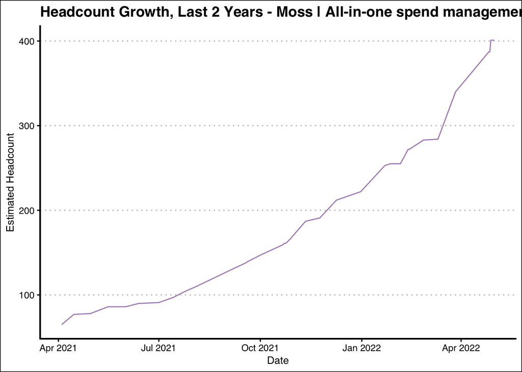

## **BRANDED**

**Company:** BRANDED  
**Country (Operating):** Schinkelplatz 5, 10117 Berlin, Germany  
**Founded Date:** January 01, 2020  
**Homepage:** https://joinbranded.com  
**Current Headcount:** 254  
**Lifetime Funding:** $150,000,000  
**Number of Funding Rounds:** 2  
**Investors:** Target Global, Vine Ventures, L.P., Kreos Capital, Kima Ventures, French Partners, C4 Ventures, Regah Ventures, Tiger Global Management, Vine Ventures, Lurra Capital AG, Jon Oringer, Declaration Partners, Mark Pincus, Global Tech Ventures, Maximilian Bittner  
**Most Recent Funding:** SERIES A - February 09, 2021  
**Sectors:** Logistics / Supply Chain, E-Commerce  
**Description:** Branded is a startup company that acquires and partners with top-performing Amazon sellers and brands.

### **Headcount**

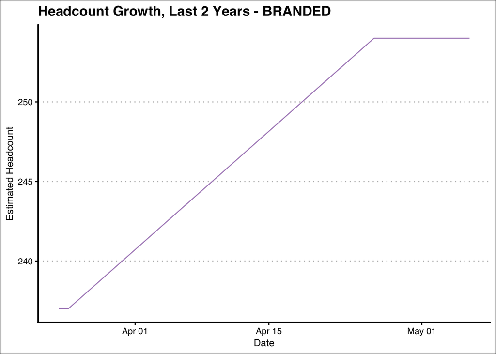

## **MoonPay**

**Company:** MoonPay  
**Country (Operating):** Miami, Florida, United States  
**Founded Date:** January 01, 2019  
**Homepage:** https://www.moonpay.com  
**Current Headcount:** 240  
**Lifetime Funding:** $642,000,000  
**Number of Funding Rounds:** 2  
**Investors:** Tribe Capital, Atacama Ventures, Streamlined Ventures, Coatue Management, Quiet Capital, Andreessen Horowitz, New Enterprise Associates (NEA), Blossom Capital, Castle Island Ventures, HOF Capital, Paradigm, Thrive Capital, Sound Ventures, Kora Management LP, The Chainsmokers, NEA, Northeast Angels, Tiger Global Management, Aubrey Graham, Time Ventures, 1/1 Capital, Night Ventures, Global Tech Ventures, Ahmir Thompson, Abel Tesfaye, 7feur Labs, Kate Hudson, Gwyneth Paltrow, Steve Aoki, Guy Oseary, Justin Bieber, Maria Sharapova, Trina Spear, Jon Hassan, Paris Hilton, NULL, Jason Derulo, Walter Bruce Willis, stacey bendet, Zoe Saldana, Yara Shahidi, Vivie-ann Bakos  
**Most Recent Funding:** SERIES A - April 13, 2022  
**Sectors:** Financial Technology, Financial / Insurance Services, Blockchain / Crypto  
**Description:** MoonPay is a financial technology company that builds payments infrastructure for crypto.

### **Headcount**

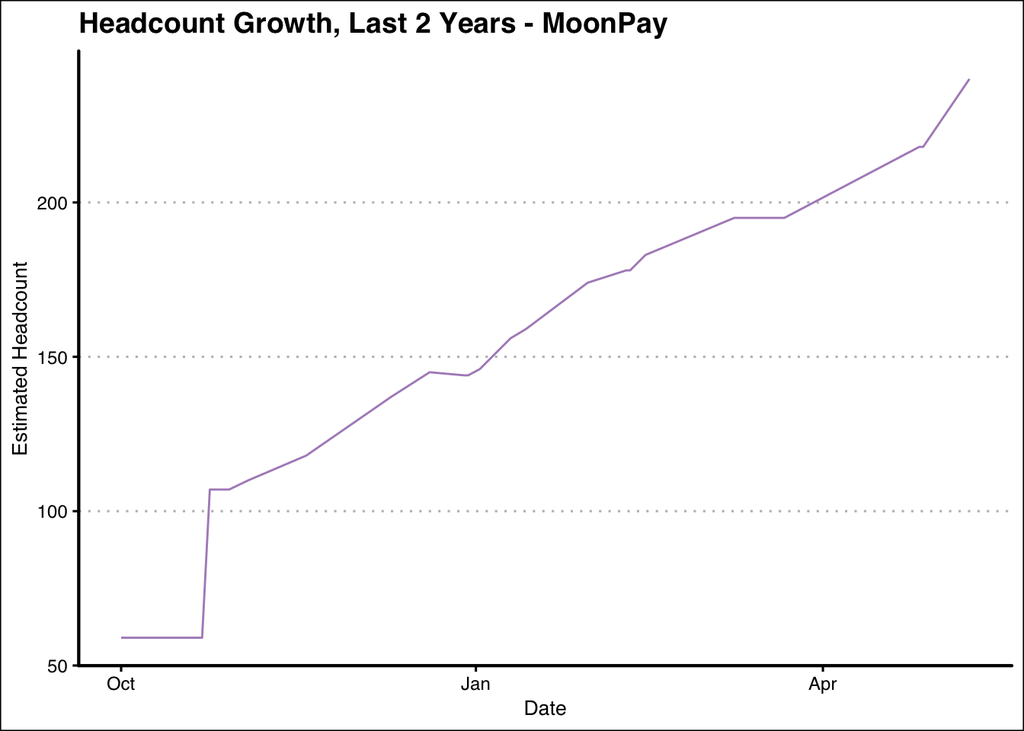

### **Traffic**

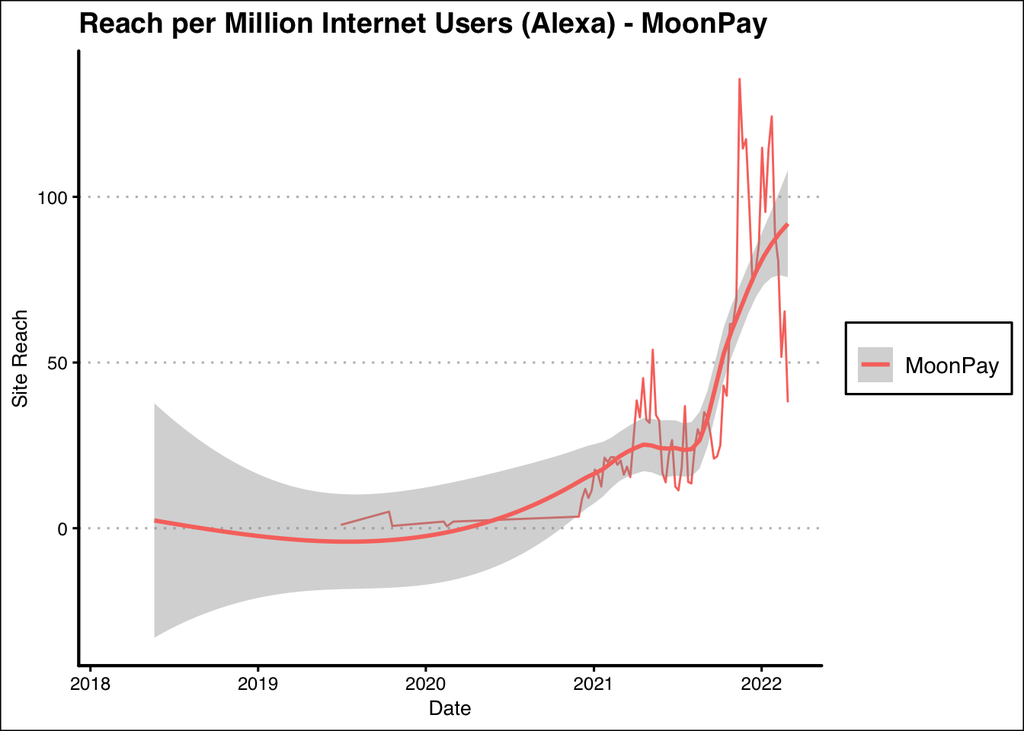

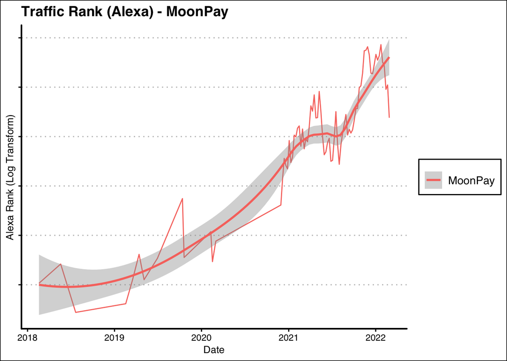